# Paquetes avanzados R

Carmen Gutiérrez Rebollo

2025-03-30

# Introducción: análisis exploratorio y limpieza de datos

Se comienza explorando el data frame. Como se puede observar, deben hacerse modificaciones sustanciales a la naturaleza de las variables. Por ello, procedemos a la conversión a numérico de las variables que lo precisas además de eliminar las columnas no válidas por contener solo datos NAs. Asimismo, modificamos la columna “AGES” para poder operar con esta. En lo que respecta a precios, como se verá en este primer apartado, las preguntas de investigación han sido muy reducidas. La inoperatividad de los datos nos ha llevado a optar por preguntar a otros conjuntos de datos.

```r
lego_population <- read.csv("lego_population_cof.csv",sep = ",", header = TRUE, stringsAsFactors = FALSE)

lego_population <- as.data.table(lego_population)
class(lego_population)
```

```
## [1] "data.table" "data.frame"
```

```r
summary(lego_population)
```

```
##        X          Item_Number          Set_Name         Amazon_Price
##  Min.   :   1.0   Length:2307        Length:2307        Length:2307
##  1st Qu.: 577.5   Class :character   Class :character   Class :character
##  Median :1154.0   Mode  :character   Mode  :character   Mode  :character
##  Mean   :1154.0
##  3rd Qu.:1730.5
##  Max.   :2307.0
##
##       Year       Pages         unique_pieces       Theme
##  Min.   :2018   Mode:logical   Min.   :   1.0   Length:2307
##  1st Qu.:2018   NA's:2307      1st Qu.:  39.0   Class :character
##  Median :2019                  Median :  83.0   Mode  :character
##  Mean   :2019                  Mean   : 118.6
##  3rd Qu.:2020                  3rd Qu.: 164.0
##  Max.   :2020                  Max.   :1067.0
##  NA's   :974                   NA's   :1008
##      Pieces      Price             Ages            Minifigures
##  Min.   :   1   Mode:logical   Length:2307        Min.   : 1.000
##  1st Qu.:  70   NA's:2307      Class :character   1st Qu.: 1.000
##  Median : 193                  Mode  :character   Median : 3.000
##  Mean   : 397                                     Mean   : 3.202
##  3rd Qu.: 456                                     3rd Qu.: 4.000
##  Max.   :9036                                     Max.   :28.000
##  NA's   :986                                      NA's   :1398
##   Packaging            Weight          Availability           Size
##  Length:2307        Length:2307        Length:2307        Length:2307
##  Class :character   Class :character   Class :character   Class :character
##  Mode  :character   Mode  :character   Mode  :character   Mode  :character
##
##
##
##
```

```r
dim(lego_population)
```

```
## [1] 2307   16
```

```r
head(lego_population)
```

```
##        X Item_Number Set_Name Amazon_Price  Year  Pages unique_pieces  Theme
##    <int>      <char>   <char>       <char> <int> <lgcl>         <int> <char>
## 1:     1           -     <NA>                 NA     NA            NA   <NA>
## 2:     2           -     <NA>                 NA     NA            NA   <NA>
## 3:     3           -     <NA>            -    NA     NA            NA   <NA>
## 4:     4           -     <NA>            -    NA     NA            NA   <NA>
## 5:     5           -     <NA>       €50.90    NA     NA            NA   <NA>
## 6:     6           -     <NA>       €45.04    NA     NA            NA   <NA>
##    Pieces  Price    Ages Minifigures Packaging Weight Availability   Size
##     <int> <lgcl>  <char>       <int>    <char> <char>       <char> <char>
## 1:     NA     NA Ages_NA          NA      <NA>   <NA>         <NA>   <NA>
## 2:     NA     NA Ages_NA          NA      <NA>   <NA>         <NA>   <NA>
## 3:     NA     NA Ages_NA          NA      <NA>   <NA>         <NA>   <NA>
## 4:     NA     NA Ages_NA          NA      <NA>   <NA>         <NA>   <NA>
## 5:     NA     NA Ages_NA          NA      <NA>   <NA>         <NA>   <NA>
## 6:     NA     NA Ages_NA          NA      <NA>   <NA>         <NA>   <NA>
```

```r
str(lego_population)
```

```
## Classes 'data.table' and 'data.frame':   2307 obs. of  16 variables:
##  $ X            : int  1 2 3 4 5 6 7 8 9 10 ...
##  $ Item_Number  : chr  "-" "-" "-" "-" ...
##  $ Set_Name     : chr  NA NA NA NA ...
##  $ Amazon_Price : chr  "" "" "-" "-" ...
##  $ Year         : int  NA NA NA NA NA NA NA NA NA NA ...
##  $ Pages        : logi  NA NA NA NA NA NA ...
##  $ unique_pieces: int  NA NA NA NA NA NA NA NA NA NA ...
##  $ Theme        : chr  NA NA NA NA ...
##  $ Pieces       : int  NA NA NA NA NA NA NA NA NA NA ...
##  $ Price        : logi  NA NA NA NA NA NA ...
##  $ Ages         : chr  "Ages_NA" "Ages_NA" "Ages_NA" "Ages_NA" ...
##  $ Minifigures  : int  NA NA NA NA NA NA NA NA NA NA ...
##  $ Packaging    : chr  NA NA NA NA ...
##  $ Weight       : chr  NA NA NA NA ...
##  $ Availability : chr  NA NA NA NA ...
##  $ Size         : chr  NA NA NA NA ...
##  - attr(*, ".internal.selfref")=<externalptr>
```

```r
glimpse(as_tibble(lego_population))
```

```
## Rows: 2,307
## Columns: 16
## $ X             <int> 1, 2, 3, 4, 5, 6, 7, 8, 9, 10, 11, 12, 13, 14, 15, 16, 1…
## $ Item_Number   <chr> "-", "-", "-", "-", "-", "-", "-", "-", "-", "-", "-", "…
## $ Set_Name      <chr> NA, NA, NA, NA, NA, NA, NA, NA, NA, NA, NA, NA, NA, NA, …
## $ Amazon_Price  <chr> "", "", "-", "-", "€50.90", "€45.04", "", "-", "-", "€72…
## $ Year          <int> NA, NA, NA, NA, NA, NA, NA, NA, NA, NA, NA, NA, NA, NA, …
## $ Pages         <lgl> NA, NA, NA, NA, NA, NA, NA, NA, NA, NA, NA, NA, NA, NA, …
## $ unique_pieces <int> NA, NA, NA, NA, NA, NA, NA, NA, NA, NA, NA, NA, NA, NA, …
## $ Theme         <chr> NA, NA, NA, NA, NA, NA, NA, NA, NA, NA, NA, NA, NA, NA, …
## $ Pieces        <int> NA, NA, NA, NA, NA, NA, NA, NA, NA, NA, NA, NA, NA, NA, …
## $ Price         <lgl> NA, NA, NA, NA, NA, NA, NA, NA, NA, NA, NA, NA, NA, NA, …
## $ Ages          <chr> "Ages_NA", "Ages_NA", "Ages_NA", "Ages_NA", "Ages_NA", "…
## $ Minifigures   <int> NA, NA, NA, NA, NA, NA, NA, NA, NA, NA, NA, NA, NA, NA, …
## $ Packaging     <chr> NA, NA, NA, NA, NA, NA, NA, NA, NA, NA, NA, NA, NA, NA, …
## $ Weight        <chr> NA, NA, NA, NA, NA, NA, NA, NA, NA, NA, NA, NA, NA, NA, …
## $ Availability  <chr> NA, NA, NA, NA, NA, NA, NA, NA, NA, NA, NA, NA, NA, NA, …
## $ Size          <chr> NA, NA, NA, NA, NA, NA, NA, NA, NA, NA, NA, NA, NA, NA, …
```

Procedemos a eliminar columnas con todos los datos NAs.

```r
cols_to_remove <- which(sapply(lego_population, function(x) all(is.na(x))))
lego_population <- lego_population[, -cols_to_remove, with = FALSE]
print(cols_to_remove)
```

```
## Pages Price
##     6    10
```

Modificamos datos de edad eliminando AGES_NA y término AGES.

```r
# Eliminamos AGES y AGES NA
lego_population[, Ages := na_if(Ages, "Ages_NA")]
lego_population[, Ages := na_if(Ages, "Ages_")]

# Eliminar el prefijo "Ages_" en las edades
lego_population[, Ages := gsub("Ages_", "", Ages)]
unique(lego_population$Ages)
```

```
##  [1] NA       "16+"    "12+"    "18+"    "5 - 99" "4 - 99" "4 - 7"  "4+"
##  [9] "1 - 3"  "2 - 5"  "2+"     "1+"     "5+"     "6+"     "6 - 14" "7 - 14"
## [17] "8+"     "7+"     "10+"    "5 - 12" "6 - 12" "6 - 10" "7 - 12" "5 - 10"
## [25] "8 - 12" "9 - 14" "9+"     "9 - 12" "8 - 14" "11+"    "3+"     "3 - 6"
## [33] "2 - 6"  "4 - 6"  "14+"
```

Contamos con intervalos en los propios datos que impiden la transformacióna numérica. Podríamos hacer una modificación buscando calcular el promedio (tras modificar los intervalos 4-99 y 5-99). No obstante, no recogería el grupo de población real al que está dirigido el producto. Entendiendo que los intervalos funcionan como categorías para la organización del producto, optamos por dejarlo así. Esto afectará a la representación gráfica de los mismos.

Conversión Amazon Prime a Numérico.

```r
lego_population[, Amazon_Price := gsub("€", "", Amazon_Price)]
lego_population[, Amazon_Price := gsub(",", ".", Amazon_Price)]
lego_population[, Amazon_Price := as.numeric(Amazon_Price)]
summary(lego_population$Amazon_Price)
```

```
##    Min. 1st Qu.  Median    Mean 3rd Qu.    Max.    NA's
##    3.99   14.66   24.99   35.78   44.99  349.99    1875
```

# **¿Cuál es la media y mediana en los precios que reciben los productos en la plataforma amazon**?

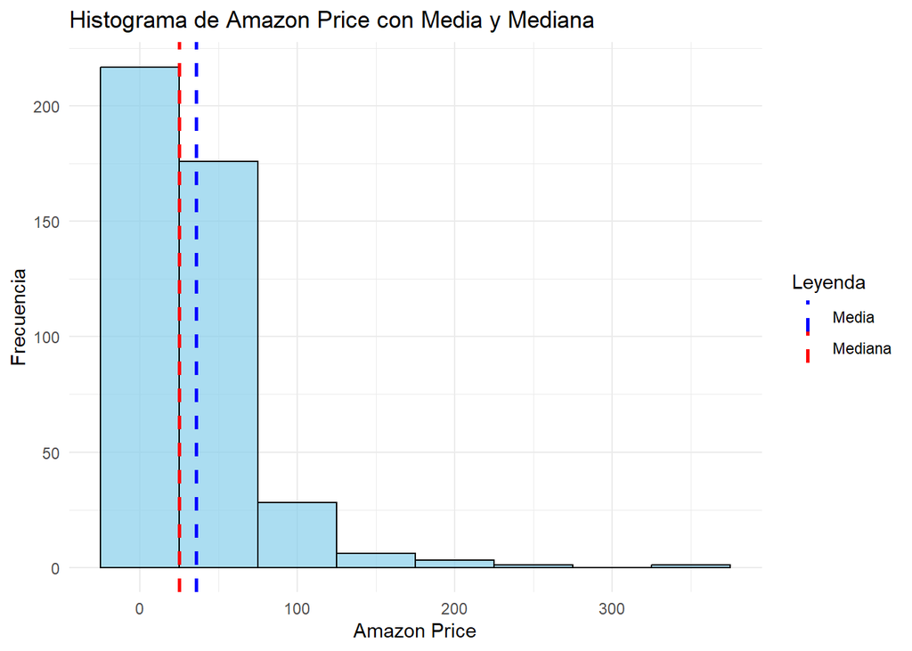

```r
mean_value <- mean(lego_population$Amazon_Price, na.rm = TRUE)
median_value <- median(lego_population$Amazon_Price, na.rm = TRUE)


mean_value <- mean(lego_population$Amazon_Price, na.rm = TRUE)
median_value <- median(lego_population$Amazon_Price, na.rm = TRUE)


ggplot(lego_population, aes(x = Amazon_Price)) +
  geom_histogram(binwidth = 50, fill = "skyblue", color = "black", alpha = 0.7) +
  geom_vline(aes(xintercept = mean_value, color = "Media"), linetype = "dashed", size = 1) +
  geom_vline(aes(xintercept = median_value, color = "Mediana"), linetype = "dashed", size = 1) +
  labs(title = "Histograma de Amazon Price con Media y Mediana",
       x = "Amazon Price",
       y = "Frecuencia",
       color = "Leyenda") +
  scale_color_manual(values = c("Media" = "blue", "Mediana" = "red")) +
  theme_minimal()
```

Los datos se encuentran sesgados, siendo la media mayor que la mediana. Encontramos asimetría positiva

Quisimos evaluar el proceso de transformación de los datos de Amazon Price con respecto a los años de salida de los productos. No obstante la dispersión de datos provocada por el volumen de datos NAs inutiliza la representación gráfica, ya que como podemos observar el número de NAs asciende a 1875.

```r
summary(lego_population$Year)
```

```
##    Min. 1st Qu.  Median    Mean 3rd Qu.    Max.    NA's
##    2018    2018    2019    2019    2020    2020     974
```

```r
summary(lego_population$Amazon_Price)
```

```
##    Min. 1st Qu.  Median    Mean 3rd Qu.    Max.    NA's
##    3.99   14.66   24.99   35.78   44.99  349.99    1875
```

Convertir Year a numérico

```r
unique(lego_population$Year[is.na(as.numeric(as.character(lego_population$Year)))])
```

```
## [1] NA
```

```r
lego_population$Year <- as.numeric(as.character(lego_population$Year))
```

Convertir peso a valor numérico

```r
invalid_weight_values <- lego_population$Weight[is.na(lego_population$Weight)]
unique(invalid_weight_values)
```

```
## [1] NA
```

```r
lego_population[, Weight := gsub("Kg", "", Weight)]
lego_population[, Weight := gsub("\\s*\\(.*?\\)", "", Weight)]
lego_population[is.na(Weight), Weight := NA]
lego_population[, Weight := as.numeric(Weight)]
```

Convertir piezas a valor numérico

```r
invalid_pieces_values <- lego_population$Pieces[is.na(lego_population$Pieces)]
unique(invalid_pieces_values)
```

```
## [1] NA
```

```r
lego_population[, Pieces := as.numeric(Pieces)]
```

Convertir mini figures a valor numérico

```r
lego_population[, Minifigures := as.numeric(Minifigures)]
```

Unique pieces a valor numérico

```r
lego_population[, unique_pieces := as.numeric(unique_pieces)]
summary(lego_population$unique_pieces)
```

```
##    Min. 1st Qu.  Median    Mean 3rd Qu.    Max.    NA's
##     1.0    39.0    83.0   118.6   164.0  1067.0    1008
```

# ¿A qué grupo de edad está dirigida la mayoría del producto? ¿En qué año se ha producido y para qué grupo de edad?

```r
#CALCULAMOS LA EDAD  A LA MAYORÍA DEL  QUE VA DIRIGIDA EL PRODUCTO
category_counts <- lego_population[!is.na(Ages), .N, by = Ages]
most_frequent_category <- category_counts[order(-N)][1]
most_frequent_category
```

```
##      Ages     N
##    <char> <int>
## 1:     7+   135
```

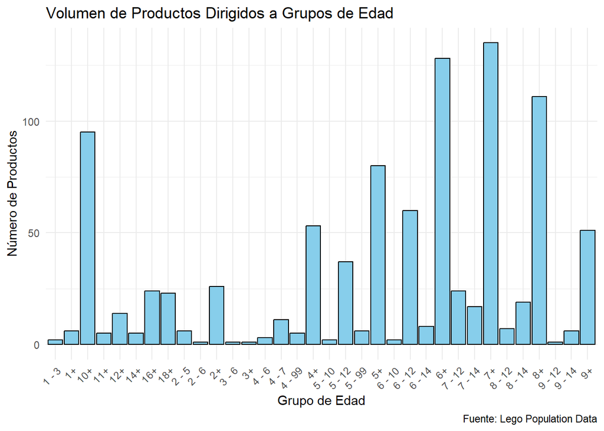

```r
#REPRESENTAMOS GRÁFICAMENTE
ggplot(category_counts, aes(x = Ages, y = N)) +
  geom_bar(stat = "identity", fill = "skyblue", color = "black") +
  labs(title = "Volumen de Productos Dirigidos a Grupos de Edad",
       x = "Grupo de Edad",
       y = "Número de Productos",
       caption = "Fuente: Lego Population Data") +
  theme_minimal() +
  theme(axis.text.x = element_text(angle = 45, hjust = 1))
```

# ¿Cuál es la frecuencia de producto por grupo de edad?

```r
lego_population <- lego_population[!is.na(Ages) & !is.na(Set_Name)]
category_counts_ages <- lego_population[, .N, by = .(Set_Name, Ages)]
most_frequent_ages <- category_counts_ages[, .SD[which.max(N)], by = Ages]

print(most_frequent_ages)
```

```
##       Ages                                Set_Name     N
##     <char>                                  <char> <int>
##  1:    16+                          Downtown Diner     1
##  2:    12+             Winter Village Fire Station     1
##  3:    18+                           Haunted House     1
##  4: 5 - 99                             Rainbow Fun     1
##  5: 4 - 99                       Creative Suitcase     1
##  6:  4 - 7                        Emma's Pet Party     1
##  7:     4+                              Woody & RC     1
##  8:  1 - 3                       My First Ladybird     1
##  9:  2 - 5                 Train Bridge and Tracks     1
## 10:     2+                 Mickey's Vacation House     1
## 11:     1+                               Heart Box     1
## 12:     5+                    City Advent Calendar     2
## 13:     6+                   Botanical Accessories     2
```

[output cut: 22 more lines]

```r
lego_population <- lego_population[!is.na(Ages) & !is.na(Set_Name)]


category_counts_ages <- lego_population[, .N, by = .(Set_Name, Ages)]


most_frequent_ages <- category_counts_ages[order(-N), .SD[1], by = Ages]


print(most_frequent_ages)
```

```
##       Ages                                Set_Name     N
##     <char>                                  <char> <int>
##  1:     6+                   Botanical Accessories     2
##  2:     5+                    City Advent Calendar     2
##  3:     7+            Harry Potter Advent Calendar     2
##  4:    16+                          Downtown Diner     1
##  5:    12+             Winter Village Fire Station     1
##  6:    18+                           Haunted House     1
##  7: 5 - 99                             Rainbow Fun     1
##  8: 4 - 99                       Creative Suitcase     1
##  9:  4 - 7                        Emma's Pet Party     1
## 10:     4+                              Woody & RC     1
## 11:  1 - 3                       My First Ladybird     1
## 12:  2 - 5                 Train Bridge and Tracks     1
## 13:     2+                 Mickey's Vacation House     1
```

[output cut: 22 more lines]

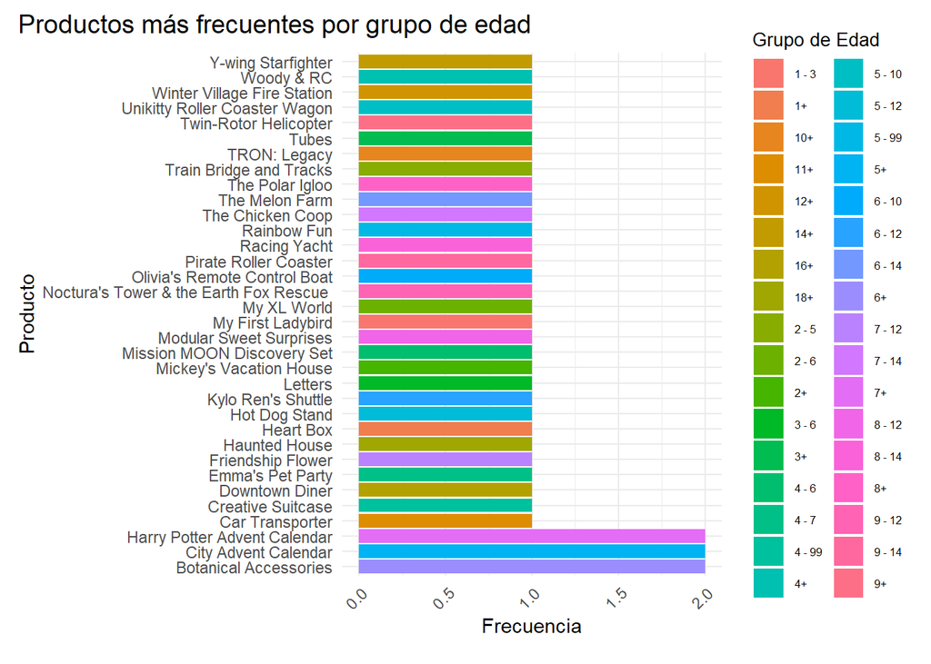

```r
ggplot(most_frequent_ages, aes(x = reorder(Set_Name, -N), y = N, fill = Ages)) +
  geom_bar(stat = "identity") +
  coord_flip() +
  labs(title = "Productos más frecuentes por grupo de edad",
       x = "Producto",
       y = "Frecuencia",
       fill = "Grupo de Edad") +
  theme_minimal() +
  theme(axis.text.x = element_text(angle = 45, hjust = 1),
        plot.title = element_text(size = 14, vjust = 2),
        plot.margin = margin(10, 10, 15, 10),
        plot.title.position = "plot",
        legend.text = element_text(size = 6),
        legend.title = element_text(size = 10))
```

Como podemos observar con o sin representación gráfica es el elevado número de productos individuales que casi coincide con el número de filas.

# ¿Qué número de piezas contienen los productos según edad?

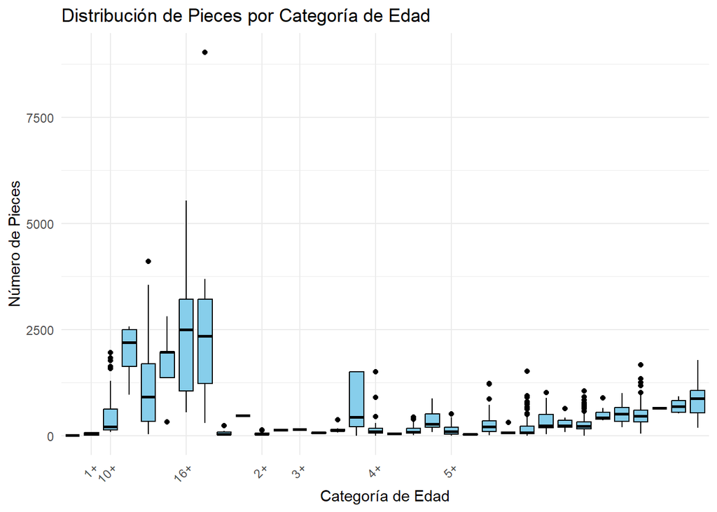

```r
library(ggplot2)

ggplot(lego_population, aes(x = Ages, y = Pieces)) +
  geom_boxplot(fill = "skyblue", color = "black") +
  labs(title = "Distribución de Pieces por Categoría de Edad",
       x = "Categoría de Edad",
       y = "Número de Pieces") +
  scale_x_discrete(
    breaks = c("1-3","1+", "2+","3+", "4+", "5+","2-5", "5+", "7", "4-7", "6-12", "10+", "16+"),
    labels = c("1-3","1+", "2+","3+", "4+", "5+","2-5", "5+", "7", "4-7", "6-12", "10+", "16+")
  ) +
  theme_minimal() +
  theme(axis.text.x = element_text(angle = 45, hjust = 1))
```

# ¿Cuál es la media de todas las variables numéricas?

```r
lego_population <- lego_population[, !c("V1", "Item_Number"), with = FALSE]
media_columnas <- lego_population[, lapply(.SD, mean, na.rm = TRUE), .SDcols = is.numeric]


print(media_columnas)
```

```
##           X Amazon_Price     Year unique_pieces   Pieces Minifigures    Weight
##       <num>        <num>    <num>         <num>    <num>       <num>     <num>
## 1: 1524.085          NaN 2019.069      131.3615 440.0513    3.286313 0.6768794
```

# ¿Existe correlación entre la disponibilitad y temática del producto?

```r
tabla <- table(lego_population$Availability, lego_population$Theme)
chi_test <- chisq.test(tabla)
print(chi_test)
```

```
##
##  Pearson's Chi-squared test
##
## data:  tabla
## X-squared = 2105, df = 276, p-value < 2.2e-16
```

Matriz de correlación. Se valora positiva la realización de una matriz de correlación y establecer una correlación entre variables. Al haber tantos valores NAs no es posible.

# ¿Existe relación entre el año de venta/edición del producto y la disponibilidad?

```r
lego_population[, .(Year, Availability)]
```

```
##       Year     Availability
##      <num>           <char>
##   1:  2018   LEGO exclusive
##   2:  2018   LEGO exclusive
##   3:  2018   LEGO exclusive
##   4:  2019   LEGO exclusive
##   5:  2019   LEGO exclusive
##  ---
## 971:  2018   LEGO exclusive
## 972:  2019   LEGO exclusive
## 973:  2019   LEGO exclusive
## 974:  2020 Retail - limited
## 975:  2020 Retail - limited
```

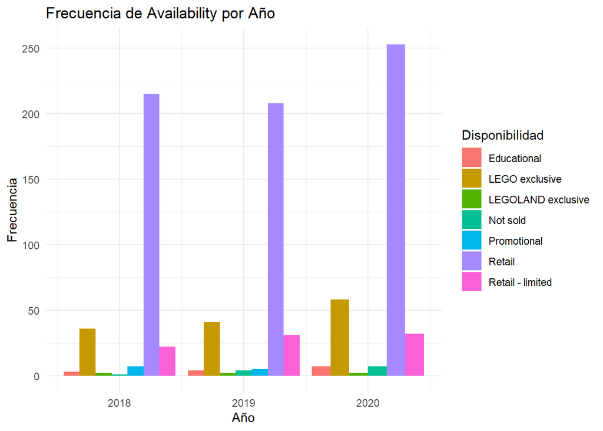

```r
resultado <- lego_population[, .(count = .N), by = .(Year, Availability)]

category_counts_availability <- lego_population[!is.na(Availability) & !is.na(Year), .N, by = .(Year, Availability)]

most_frequent_availability_year <- category_counts_availability[order(-N)][1]

#Representamos gráficamente. Paquete gplott
ggplot(category_counts_availability, aes(x = Year, y = N, fill = Availability)) +
  geom_bar(stat = "identity", position = "dodge") +
  labs(title = "Frecuencia de Availability por Año",
       x = "Año",
       y = "Frecuencia",
       fill = "Disponibilidad") +
  theme_minimal()
```